# List columns and regressions

## Introduction

We will learn how to use list-columns created with `nest()` (or `split()`), together with `map()` to run many regressions and then gather the results with `broom()`.

## Libraries

We will use the following libraries.

```r
library(tidyverse)
library(broom)
library(dataregacc)
```

## Data

We create and tidy the data. We are going to use employees in persons and hours worked by Nace. We will have them in wide format.

```r
data <- regacc %>%
  filter(NUTS==2 &
         na_item=="SAL" &
         table %in% c("3emp","2emphw") &
         !country %in% c("AL","MK", "ME", "RS", "TR", "NO") &
         !str_ends(geo,"ZZ")) %>%
  select(geo,unit,nace_r2,time, values) %>%
  na.omit() %>%
  pivot_wider(names_from = unit,
        values_from = values)

head(data)
```

```
## # A tibble: 6 x 5
##   geo   nace_r2  time    PS     HW
##   <fct> <fct>   <int> <dbl>  <dbl>
## 1 SK04  TOTAL    2000  454. 782881
## 2 SK04  TOTAL    2001  453. 774814
## 3 SK04  TOTAL    2002  441. 730891
## 4 SK04  TOTAL    2003  448. 717128
## 5 SK04  TOTAL    2004  433. 710032
## 6 SK04  TOTAL    2005  421. 703462
```

## group_by() and nest()

We do a `group_by()` followed by `nest()`.

```r
data_nested <- data %>%
  group_by(geo,nace_r2) %>%
  nest()
```

We have one row by geo and nace and a tibble attached to each row.

```r
head(data_nested)
```

```
## # A tibble: 6 x 3
## # Groups:   geo, nace_r2 [6]
##   geo   nace_r2 data
##   <fct> <fct>   <list>
## 1 SK04  TOTAL   <tibble [21 x 3]>
## 2 SK04  A       <tibble [20 x 3]>
## 3 SK04  B-E     <tibble [20 x 3]>
## 4 SK04  C       <tibble [20 x 3]>
## 5 SK04  F       <tibble [20 x 3]>
## 6 SK04  G-J     <tibble [20 x 3]>
```

Each tibble contains three columns: time, HW and PS

```r
head(data_nested$data,1)
```

```
## [[1]]
## # A tibble: 21 x 3
##     time    PS     HW
##    <int> <dbl>  <dbl>
##  1  2000  454. 782881
##  2  2001  453. 774814
##  3  2002  441. 730891
##  4  2003  448. 717128
##  5  2004  433. 710032
##  6  2005  421. 703462
##  7  2006  440. 736045
##  8  2007  428. 717569
##  9  2008  440. 736443
## 10  2009  415. 688931
## # ... with 11 more rows
```

## Doing the regressions

We can now run the 3630 regressions.

```r
data_nested <- data_nested %>%
  mutate(model = map(data, ~ lm(HW ~ PS, data = .x)))

head(data_nested$model,1)
```

```
## [[1]]
##
## Call:
## lm(formula = HW ~ PS, data = .x)
##
## Coefficients:
## (Intercept)           PS
##      239026         1114
```

We have now a new column containing the regression model. We now rely in `broom()` to extract more easily the results.

## Broom::tidy()

With `tidy()` we collect information on the parameters, the standard error or the p-value.

```r
data_nested<- data_nested %>%
  mutate(tidy = map(model, tidy))

head(data_nested$tidy,1)
```

```
## [[1]]
## # A tibble: 2 x 5
##   term        estimate std.error statistic     p.value
##   <chr>          <dbl>     <dbl>     <dbl>       <dbl>
## 1 (Intercept)  239026.    66679.      3.58 0.00212
## 2 PS             1114.      150.      7.45 0.000000668
```

## Broom::augment()

With `augment()` we get the fitted results and other information.

```r
data_nested<- data_nested %>%
  mutate(augment = map(model, augment))

head(data_nested$augment,1)
```

```
## [[1]]
## # A tibble: 20 x 8
##        HW    PS .fitted  .resid   .hat .sigma   .cooksd .std.resid
##     <dbl> <dbl>   <dbl>   <dbl>  <dbl>  <dbl>     <dbl>      <dbl>
##  1 782881  454. 744647.  38234. 0.0582 10921. 0.241         2.79
##  2 774814  453. 743856.  30958. 0.0569 12280. 0.154         2.26
##  3 730891  441. 729949.    942. 0.0524 14509. 0.000130      0.0686
##  4 717128  448. 738106. -20978. 0.0508 13539. 0.0624       -1.53
##  5 710032  433. 721246. -11214. 0.0675 14235. 0.0245       -0.823
##  6 703462  421. 708419.  -4957. 0.115  14455. 0.00904      -0.374
##  7 736045  440. 729748.   6297. 0.0526 14426. 0.00584       0.459
##  8 717569  428. 716443.   1126. 0.0816 14508. 0.000309      0.0833
##  9 736443  440. 729158.   7285. 0.0532 14397. 0.00792       0.531
## 10 688931  415. 701845. -12914. 0.150  14107. 0.0874       -0.993
## 11 709822  421. 707628.   2194. 0.119  14500. 0.00185       0.166
## 12 712406  428. 715551.  -3145. 0.0847 14489. 0.00252      -0.233
## 13 727964  436. 725101.   2863. 0.0591 14493. 0.00138       0.209
## 14 716724  435. 723341.  -6617. 0.0626 14416. 0.00784      -0.485
## 15 728118  441. 730918.  -2800. 0.0516 14494. 0.00113      -0.204
## 16 738301  449. 739399.  -1098. 0.0517 14508. 0.000174     -0.0799
## 17 751975  461. 752270.   -295. 0.0766 14511. 0.0000196    -0.0217
## 18 763662  477. 770924.  -7262. 0.166  14382. 0.0317       -0.564
## 19 775442  488. 783093.  -7651. 0.259  14350. 0.0692       -0.630
## 20 779947  495. 790916. -10969. 0.332  14141. 0.225        -0.952
```

## Broom::glance()

With `glance()` we get some summary information like the R<sup>2</sup>, the AIC or the BIC.

```r
data_nested<- data_nested %>%
  mutate(glance = map(model, glance))

head(data_nested$glance,1)
```

```
## [[1]]
## # A tibble: 1 x 12
##   r.squared adj.r.squared  sigma statistic     p.value    df logLik   AIC   BIC
##       <dbl>         <dbl>  <dbl>     <dbl>       <dbl> <dbl>  <dbl> <dbl> <dbl>
## 1     0.755         0.741 14102.      55.5 0.000000668     1  -218.  443.  446.
## # ... with 3 more variables: deviance <dbl>, df.residual <int>, nobs <int>
```

We have now all that information together in the dataframe.

```r
glimpse(data_nested)
```

```
## Rows: 3,630
## Columns: 7
## Groups: geo, nace_r2 [3,630]
## $ geo     <fct> SK04, SK04, SK04, SK04, SK04, SK04, SK04, SK04, SK04, SK04, SK~
## $ nace_r2 <fct> TOTAL, A, B-E, C, F, G-J, G-I, J, K-N, K, L, M_N, O-U, O-Q, R-~
## $ data    <list> [<tbl_df[21 x 3]>], [<tbl_df[20 x 3]>], [<tbl_df[20 x 3]>], [~
## $ model   <list> [239025.956, 1114.366, 38233.6769, 30957.8769, 942.1668, -209~
## $ tidy    <list> [<tbl_df[2 x 5]>], [<tbl_df[2 x 5]>], [<tbl_df[2 x 5]>], [<tb~
## $ augment <list> [<tbl_df[20 x 8]>], [<tbl_df[20 x 8]>], [<tbl_df[20 x 8]>], [~
## $ glance  <list> [<tbl_df[1 x 12]>], [<tbl_df[1 x 12]>], [<tbl_df[1 x 12]>], [~
```

## Unnest

Now we could unnest but we have to be careful because some columns appear in several tibbles. We can, for example, keep just the R<sup>2</sup> and plot the mean .

```r
data_unnest<- data_nested %>%
  select(-model, -tidy,-augment) %>%
  unnest(cols = c(data,glance)) %>%
  select(geo,nace_r2,PS,HW,r.squared)
```

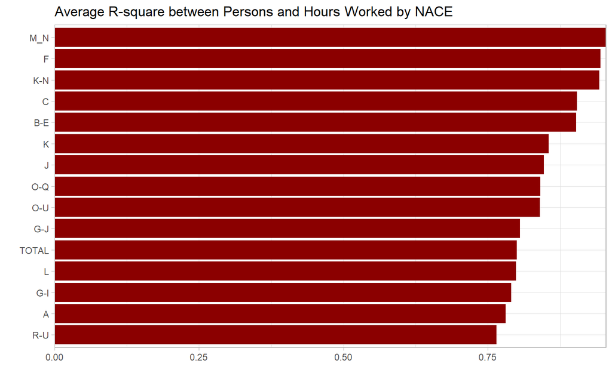

```r
mean<- data_unnest %>%
  group_by(nace_r2) %>%
  summarise(mean=mean(r.squared))

ggplot(mean,aes(mean,fct_reorder(nace_r2,mean)))+
  geom_col(fill="darkred")+
  theme_light()+
  ylab("")+ xlab("")+
  ggtitle("Average R-square between Persons and Hours Worked by NACE")+
  scale_x_continuous(expand=c(0,0))
```